# Restaurant_review_HO1

Bruno Díez Buitrago

# Introduction

The goal of this document is to show how to perform different analyses of text documents at a word level, mainly using the tm (text mining) package in R.  
This is part of the Intelligent Systems project found on https://github.com/brunaldo07/Hands-On-Project , precisely the first hands on

# Loading Corpus

We are using a reduced version of the dataset found in https://www.kaggle.com/vigneshwarsofficial/reviews containing information about restaurant reviews. It can be found in the folder “Corpus” of the containing folder “Resources” of the github project. The corpus containing all instances of the dataset can be found in the folder “reviews” under the “Resources” folder.

```r
source.pos = DirSource("../Resources/reviews", encoding = "UTF-8")
corpus = Corpus(source.pos)
```

# Inspecting the corpus

Let’s see the length of the corpus and a the first entries to see the kind of documents it includes

```r
length(corpus)
```

```
## [1] 1000
```

```r
summary(corpus[1:10])
```

```
##                 Length Class             Mode
## review_10.txt   2      PlainTextDocument list
## review_100.txt  2      PlainTextDocument list
## review_1000.txt 2      PlainTextDocument list
## review_1001.txt 2      PlainTextDocument list
## review_101.txt  2      PlainTextDocument list
## review_102.txt  2      PlainTextDocument list
## review_103.txt  2      PlainTextDocument list
## review_104.txt  2      PlainTextDocument list
## review_105.txt  2      PlainTextDocument list
## review_106.txt  2      PlainTextDocument list
```

We see it’s a group of PlainTextDocument instances If we inspect them we will see they contain metadata as well

```r
inspect(corpus[1])
```

```
## <<SimpleCorpus>>
## Metadata:  corpus specific: 1, document level (indexed): 0
## Content:  documents: 1
##
##             review_10.txt
## The fries were great too.
```

```r
inspect(corpus[[127]])
```

```
## <<PlainTextDocument>>
## Metadata:  7
## Content:  chars: 80
##
## The sides are delish - mixed mushrooms, yukon gold puree, white corn - beateous.
```

We can inspect this metadata as well

```r
meta(corpus[[127]])
```

```
##   author       : character(0)
##   datetimestamp: 2021-01-12 16:23:52
##   description  : character(0)
##   heading      : character(0)
##   id           : review_211.txt
##   language     : en
##   origin       : character(0)
```

# Term Document Matrix

We are going to create a term document matrix and look at its summary

```r
tdm = TermDocumentMatrix(corpus)
tdm
```

```
## <<TermDocumentMatrix (terms: 2658, documents: 1000)>>
## Non-/sparse entries: 8475/2649525
## Sparsity           : 100%
## Maximal term length: 38
## Weighting          : term frequency (tf)
```

```r
inspect(tdm[106:110,10:30])
```

```
## <<TermDocumentMatrix (terms: 5, documents: 21)>>
## Non-/sparse entries: 5/100
## Sparsity           : 95%
## Maximal term length: 10
## Weighting          : term frequency (tf)
## Sample             :
##             Docs
## Terms        review_106.txt review_107.txt review_108.txt review_109.txt
##   ambience                0              0              0              1
##   music                   0              0              0              1
##   personable              0              0              1              0
##   playing.                0              0              0              1
##   there                   0              0              0              1
##             Docs
## Terms        review_11.txt review_110.txt review_111.txt review_112.txt
##   ambience               0              0              0              0
##   music                  0              0              0              0
##   personable             0              0              0              0
##   playing.               0              0              0              0
##   there                  0              0              0              0
##             Docs
## Terms        review_113.txt review_114.txt
##   ambience                0              0
##   music                   0              0
##   personable              0              0
##   playing.                0              0
##   there                   0              0
```

We can see the number of terms identified in the tdm

```r
length(dimnames(tdm)$Terms)
```

```
## [1] 2658
```

Let’s see how frequently those terms appear and plot their frequencies ordered

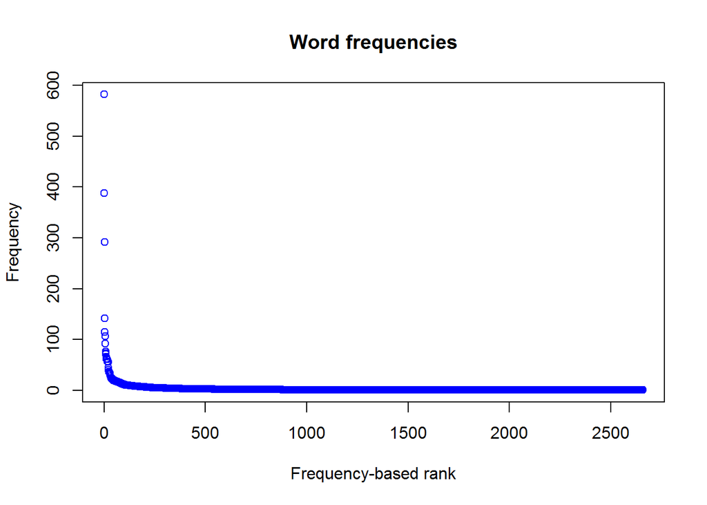

```r
freq=rowSums(as.matrix(tdm))
plot(sort(freq, decreasing = T),col="blue",main="Word frequencies", xlab="Frequency-based rank", ylab = "Frequency")
```

We can take a look at the frequencies of the terms

```r
head(freq,10)
```

```
##      fries      great        the       too.       were      good.        not
##          8         57        582          4         61         22        115
##        was        and experience
##        292        388          9
```

```r
tail(freq,10)
```

```
##  impressive     mirage.      crusty       dried     refried       else.
##           1           1           1           1           1           1
## caterpillar        lady    appetite   instantly
##           1           1           1           1
```

```r
#most frequent terms
tail(sort(freq),n=15)
```

```
##   but  good  that   are   had  with  very place  food   for   not  this   was
##    61    62    62    62    66    72    74    77    92   107   115   142   292
##   and   the
##   388   582
```

This number of terms only appear once

```r
sum(freq == 1)
```

```
## [1] 1782
```

# Create TDM with transformations and custom stopwords

We can design some custom stopwords in order to skip those terms that are not going to give us much information in the context we are working on (restaurant reviews).

```r
review =  corpus[110]
myStopwords = c(stopwords(),"food","restaurant","review")
review = tm_map(corpus[110],removeWords,myStopwords)
review[[1]]$content[1]
```

```
## [1] "The best place  go   tasty bowl  Pho!"
```

create new tdm with transformations an custom stop words

```r
tdm = TermDocumentMatrix(corpus,
                         control=list(stopwords = myStopwords,
                                      removePunctuation = T,
                                      removeNumbers = T,
                                      stemming = T))
tdm
```

```
## <<TermDocumentMatrix (terms: 1577, documents: 1000)>>
## Non-/sparse entries: 5289/1571711
## Sparsity           : 100%
## Maximal term length: 32
## Weighting          : term frequency (tf)
```

We can also show the most frequent terms and their frequencies in a bar plot.

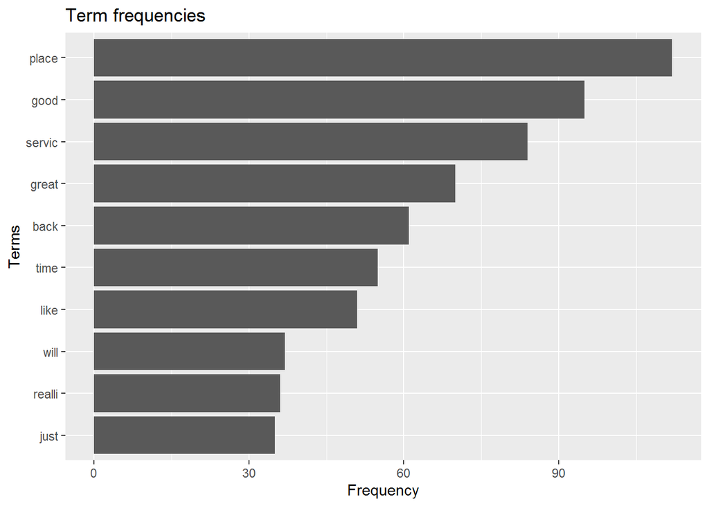

```r
freq=rowSums(as.matrix(tdm))
high.freq=tail(sort(freq),n=10)
hfp.df=as.data.frame(sort(high.freq))
hfp.df$names <- rownames(hfp.df)
ggplot(hfp.df, aes(reorder(names,high.freq), high.freq)) +
  geom_bar(stat="identity") + coord_flip() +
  xlab("Terms") + ylab("Frequency") +
  ggtitle("Term frequencies")
```

# TDM with TF-IDF weights

We take a look at the summary of the tdm resulting from applying TF-IDF weights

```r
tdm.tfidf = TermDocumentMatrix(corpus,
                               control = list(weighting = weightTfIdf,
                                              stopwords = myStopwords,
                                              removePunctuation = T,
                                              removeNumbers = T,
                                              stemming = T))
tdm.tfidf
```

```
## <<TermDocumentMatrix (terms: 1577, documents: 1000)>>
## Non-/sparse entries: 5289/1571711
## Sparsity           : 100%
## Maximal term length: 32
## Weighting          : term frequency - inverse document frequency (normalized) (tf-idf)
```

We inspect a subset of the tdm

```r
inspect(tdm.tfidf[130:150,100:200])
```

```
## <<TermDocumentMatrix (terms: 21, documents: 101)>>
## Non-/sparse entries: 5/2116
## Sparsity           : 100%
## Maximal term length: 12
## Weighting          : term frequency - inverse document frequency (normalized) (tf-idf)
## Sample             :
##           Docs
## Terms      review_188.txt review_189.txt review_19.txt review_190.txt
##   bite                  0              0             0              0
##   black                 0              0             0              0
##   blah                  0              0             0              0
##   blame                 0              0             0              0
##   bland                 0              0             0              0
##   blandest              0              0             0              0
##   blow                  0              0             0              0
##   boba                  0              0             0              0
##   bode                  0              0             0              0
##   boot                  0              0             0              0
##           Docs
## Terms      review_191.txt review_198.txt review_22.txt review_225.txt
##   bite                  0       0.000000      0.000000       0.000000
##   black                 0       0.000000      0.000000       0.000000
##   blah                  0       0.000000      4.982892       0.000000
##   blame                 0       0.000000      0.000000       0.000000
##   bland                 0       0.000000      0.000000       0.000000
##   blandest              0       0.000000      0.000000       0.000000
##   blow                  0       1.793157      0.000000       0.000000
##   boba                  0       0.000000      0.000000       0.000000
##   bode                  0       0.000000      0.000000       1.245723
##   boot                  0       0.000000      0.000000       0.000000
##           Docs
## Terms      review_265.txt review_277.txt
##   bite           0.000000      0.0000000
##   black          0.000000      0.0000000
##   blah           0.000000      0.0000000
##   blame          0.000000      0.0000000
##   bland          0.000000      0.0000000
##   blandest       0.000000      0.0000000
##   blow           0.000000      0.0000000
##   boba           0.000000      0.9961983
##   bode           0.000000      0.0000000
##   boot           1.793157      0.0000000
```

We can also plot the TF-IDF values in order and see the terms with the highest TF-IDF

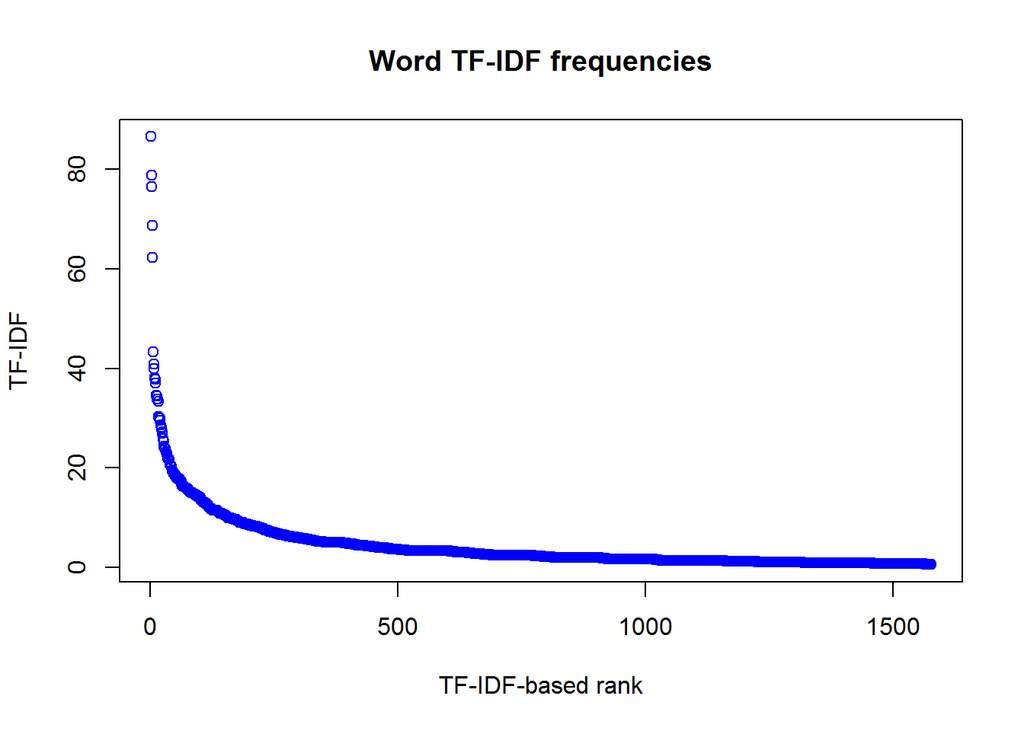

```r
freq=rowSums(as.matrix(tdm.tfidf))

plot(sort(freq, decreasing = T),col="blue",main="Word TF-IDF frequencies", xlab="TF-IDF-based rank", ylab = "TF-IDF")
```

```r
tail(sort(freq),n=10)
```

```
##       like       love       will     delici disappoint       back      great
##   37.73985   38.03099   39.97287   40.86474   43.34589   62.22685   68.65250
##      place     servic       good
##   76.50737   78.78438   86.53361
```

# Association analysis

Let’s see the words most associated with some of the most relean terms

```r
asoc.servic = as.data.frame(findAssocs(tdm,"servic", 0.2))
asoc.servic$names <- rownames(asoc.servic)
asoc.servic
```

```
##        servic  names
## slow     0.25   slow
## gotten   0.22 gotten
```

```r
asoc.delici = as.data.frame(findAssocs(tdm,"delici", 0.2))
asoc.delici$names <- rownames(asoc.delici)
asoc.delici
```

```
##              delici        names
## bunch           0.2        bunch
## caper           0.2        caper
## crawfish        0.2     crawfish
## fluffi          0.2       fluffi
## goldencrispi    0.2 goldencrispi
## handmad         0.2      handmad
## jamaican        0.2     jamaican
## lox             0.2          lox
## mojito          0.2       mojito
## multigrain      0.2   multigrain
## mussel          0.2       mussel
## nyc             0.2          nyc
## pecan           0.2        pecan
## prefer          0.2       prefer
## pumpkin         0.2      pumpkin
## reduct          0.2       reduct
## spicier         0.2      spicier
## thus            0.2         thus
```

Let’s see this last result in a bargraph.

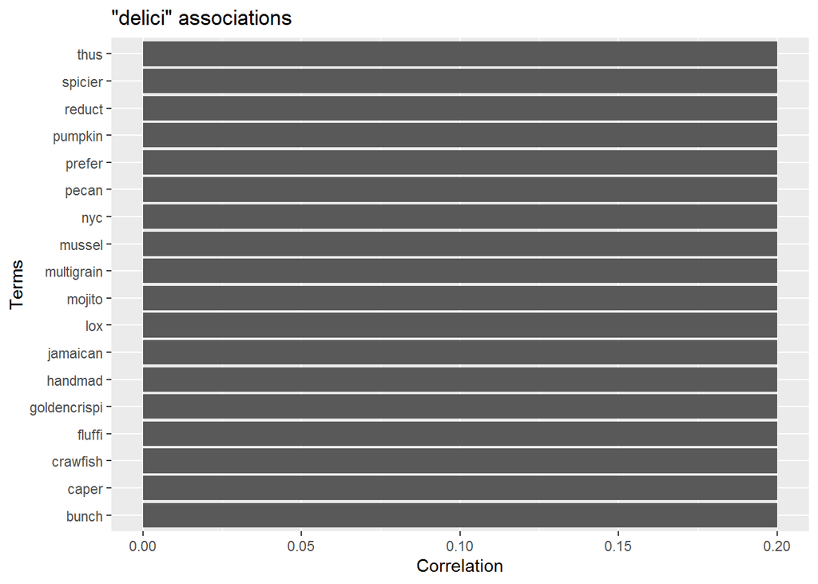

```r
ggplot(asoc.delici, aes(reorder(names,delici), delici)) +
  geom_bar(stat="identity") + coord_flip() +
  xlab("Terms") + ylab("Correlation") +
  ggtitle("\"delici\" associations")
```

Although it is not very useful since all results have the same aspect

# Word cloud

```r
pal=brewer.pal(8,"Blues")
pal=pal[-(1:3)]

set.seed(1234)
```

We create an ngram corpus

```r
corpus.ngrams = VCorpus(source.pos)

tdm.unigram = TermDocumentMatrix(corpus.ngrams,
                                control=list(stopwords = c(myStopwords,"s","ve"),
                                removePunctuation = T,
                                removeNumbers = T))
```

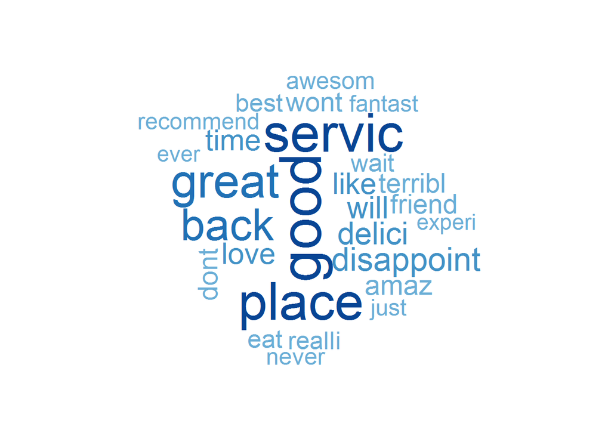

```r
word.cloud=wordcloud(words=names(freq), freq=freq,
                     min.freq=25, random.order=F, colors=pal)
```